Review

Does negative-pressure wound therapy

inﬂuence subjacent bacterial growth? A

systematic review

Graeme E. Glass <sup>a</sup><sup>,</sup><sup>b</sup><sup>,</sup>*, George R.F. Murphy <sup>c</sup>,

Jagdeep Nanchahal <sup>a</sup>

a Kennedy Institute of Rheumatology, Nufﬁeld Department of Orthopaedics, Rheumatology and

Musculoskeletal Sciences, University of Oxford, Oxford, UK

b Bart’s Health NHS Trust, The Royal London Hospital, Whitechapel Road, London, UK

c St. Hugh’s College, University of Oxford, Oxford, UK

Received 17 April 2017; accepted 10 May 2017

KEYWORDS

Negative-pressure

wound therapy;

NPWT;

Bacterial bioburden;

Non-fermentative

gram-negative bacilli;

Instillation therapy

Summary

Background: Negative-pressure wound therapy is a ubiquitous wound management

resource. The inﬂuence of NPWT on the bacterial bioburden of the subjacent wound remains

unclear. We sought to examine the evidence.

Datasources: MEDLINE, Embase, PubMed, the Cochrane Database of Systematic Reviews and

the Cochrane Controlled Trials Register were searched for articles quantitatively evaluating

bacterial load under NPWT.

Results: Twenty-four studies met the inclusion criteria including 4 randomised controlled tri-

als, 8 clinical series and 12 experimental studies. Twenty studies evaluated conventional

NPWT, while 4 evaluated inﬁltration-based NPWT. While 8 studies using conventional NPWT

failed to demonstrate an observable effect on bacterial load, 7 studies reported that NPWT

was inherently bacteriostatic and 5 others reported species selectivity with suppression of

non-fermentative gram-negative bacilli (NFGNB), including Pseudomonas spp. Simultaneously,

there was some evidence of enhanced proliferation of gram-positive cocci where the niche was

cleared of NFGNB. Two of the 4 studies using inﬁltration-based NPWT also reported selectively

impaired proliferation of Pseudomonas spp.

Conclusion: The assumption that NPWT suppresses bacterial proliferation is oversimpliﬁed.

There is evidence that NPWT exhibits species selectivity, suppressing the proliferation of

NFGNB. However, this may depopulate the niche for exploitation by gram-positive cocci. This,

* Corresponding author. Kennedy Institute of Rheumatology, Nufﬁeld Department of Orthopaedics, Rheumatology & Musculoskeletal

Sciences, University of Oxford, Roosevelt Drive, OX3 7FY, UK.

E-mail addresses: drgraemeglass@gmail.com (G.E. Glass), George.murphy@st-hugh’s.ox.ac.uk (G.R.F. Murphy), jagdeep.nanchahal@

kennedy.ox.ac.uk (J. Nanchahal).

http://dx.doi.org/10.1016/j.bjps.2017.05.027

[figure not shown]

[figure not shown]

in turn, has implications for the use of NPWT where highly virulent strains of gram-positive

cocci have been isolated and the duration of NPWT therapy and frequency of dressing changes.

ª 2017 British Association of Plastic, Reconstructive and Aesthetic Surgeons. Published by Else-

vier Ltd. All rights reserved.

Contents

Introduction

. . . . . . . . . . . . . . . . . . . . . . . . . . . . . . . . . . . . . . . . . . . . . . . . . . . . . . . . . . . . . . . . . . . . . . . . 1029

Patients and methods . . . . . . . . . . . . . . . . . . . . . . . . . . . . . . . . . . . . . . . . . . . . . . . . . . . . . . . . . . . . . . . . . . 1029

Search strategy . . . . . . . . . . . . . . . . . . . . . . . . . . . . . . . . . . . . . . . . . . . . . . . . . . . . . . . . . . . . . . . . . . . .1029

Inclusion criteria . . . . . . . . . . . . . . . . . . . . . . . . . . . . . . . . . . . . . . . . . . . . . . . . . . . . . . . . . . . . . . . . . . .1030

Exclusion criteria . . . . . . . . . . . . . . . . . . . . . . . . . . . . . . . . . . . . . . . . . . . . . . . . . . . . . . . . . . . . . . . . . . .1030

Outcome measures . . . . . . . . . . . . . . . . . . . . . . . . . . . . . . . . . . . . . . . . . . . . . . . . . . . . . . . . . . . . . . . . . .1030

Study selection . . . . . . . . . . . . . . . . . . . . . . . . . . . . . . . . . . . . . . . . . . . . . . . . . . . . . . . . . . . . . . . . . . . .1030

Data extraction . . . . . . . . . . . . . . . . . . . . . . . . . . . . . . . . . . . . . . . . . . . . . . . . . . . . . . . . . . . . . . . . . . . .1030

Results . . . . . . . . . . . . . . . . . . . . . . . . . . . . . . . . . . . . . . . . . . . . . . . . . . . . . . . . . . . . . . . . . . . . . . . . . . . . 1030

General . . . . . . . . . . . . . . . . . . . . . . . . . . . . . . . . . . . . . . . . . . . . . . . . . . . . . . . . . . . . . . . . . . . . . . . . . . 1030

Experimental studies . . . . . . . . . . . . . . . . . . . . . . . . . . . . . . . . . . . . . . . . . . . . . . . . . . . . . . . . . . . . . . . .1030

Randomised controlled trials . . . . . . . . . . . . . . . . . . . . . . . . . . . . . . . . . . . . . . . . . . . . . . . . . . . . . . . . . .1030

Clinical studies

. . . . . . . . . . . . . . . . . . . . . . . . . . . . . . . . . . . . . . . . . . . . . . . . . . . . . . . . . . . . . . . . . . . .1031

Bacterial species analysis . . . . . . . . . . . . . . . . . . . . . . . . . . . . . . . . . . . . . . . . . . . . . . . . . . . . . . . . . . . . .1031

Evidence from modified NPWT regimens . . . . . . . . . . . . . . . . . . . . . . . . . . . . . . . . . . . . . . . . . . . . . . . . . .1033

Discussion . . . . . . . . . . . . . . . . . . . . . . . . . . . . . . . . . . . . . . . . . . . . . . . . . . . . . . . . . . . . . . . . . . . . . . . . . . 1034

Conflict of interest

. . . . . . . . . . . . . . . . . . . . . . . . . . . . . . . . . . . . . . . . . . . . . . . . . . . . . . . . . . . . . . . . . . . 1036

Supplementary data . . . . . . . . . . . . . . . . . . . . . . . . . . . . . . . . . . . . . . . . . . . . . . . . . . . . . . . . . . . . . . . . . . . 1036

References . . . . . . . . . . . . . . . . . . . . . . . . . . . . . . . . . . . . . . . . . . . . . . . . . . . . . . . . . . . . . . . . . . . . . . . . . 1036

Introduction

Since the publication of the seminal papers in 1997 by

Argenta and Morykwas,<sup>1,2</sup>negative-pressure wound therapy

(NPWT) has found widespread application in almost every

type of open wound and, more recently, over closed in-

cisions. Based largely on these papers, the purported

mechanisms of action, namely promotion of granulation

tissue formation, increased blood ﬂow to adjacent tissue

and bacterial clearance at the wound bed, have become

accepted and are often repeated despite the emergence of

experimental studies that have challenged some of these

assertions. More recent work has revealed a complex

rationale for the apparent clinical beneﬁts of NPWT based

on micromechanical deformation with ﬁbroblast prolifera-

tion; VEGF-mediated neo-angiogenesis; and modulation of

local and systemic expression of cytokines, growth factors,

and matrix metalloproteinases.<sup>3,4</sup>

The inﬂuence of NPWT on the microbiological environ-

ment of the subjacent wound is shrouded in confusion

owing to the plethora of variables in studies designed to

answer the question. Acute, chronic and pre-contaminated

wounds have all been investigated. Various

sampling

methods and qualitative outcome measures have been

employed. Intermittent surgical debridement and the

simultaneous use of systemic antibiotics have also compli-

cated data analysis. This study aimed to systematically

analyse the existing experimental and clinical data to

establish if NPWT acts in part by improving bacterial

clearance of the wound.

Patients and methods

Search strategy

PubMed (no date restriction), Ovid Medline (1997 to

March 2016), Embase (1997 to March 2016), the Cochrane

database

of

systematic

reviews

and

the

Cochrane

controlled trials register (searched 24 March, 2016) were

searched using medical subject heading terms and free

text terms. Articles were searched from 1997 as this year

corresponds with the ﬁrst description of the therapy as it

is used in contemporary practice. The search strategy and

terms used are shown in Supplemental Table 1. Articles

were cross-referenced to identify other articles of inter-

est. Additionally, the online trials registers Clinical-

Trials.gov

and

the

national

research

register

were

scrutinised for completed, discontinued and ongoing tri-

als relating to NPWT and bacterial growth within the

subjacent wound. The search strategy was performed in

accordance with the Cochrane Highly Sensitive Search

Strategy guideline in the Cochrane Handbook for Sys-

tematic reviews of Interventions. The review is reported

in line with the Preferred Reporting Items for Systematic

Reviews and Meta-Analyses statement.<sup>5</sup>This study was

registered

prospectively

on

the

PROSPERO

database

(CRD42016036914).

Inclusion criteria

Studies that quantitatively or semi-quantitatively evaluated

the inﬂuence of NPWT bacterial growth within the subjacent

wound were included. We included in vivo and in vitro

studies, animal models, human clinical studies and rando-

mised controlled trials. Study quality was assessed using the

Grading of Recommendations Assessment, Development and

Evaluation (GRADE) approach where study design, risks of

bias, imprecision, inconsistency and indirectness to draw

reasoned conclusions about the quality of evidence.<sup>6,7</sup>

Exclusion criteria

Publications prior to the contemporary description of NPWT

(pre-1997), descriptive studies reporting qualitative data

and studies lacking a control intervention were excluded.

Studies using non-proprietary forms of NPWT such as Redon

drains, wall-mounted suction or vacuum chambers were

also excluded.

Outcome measures

The primary outcome measures were quantitative bacterial

counts from tissue specimens or surface swabs of the subja-

cent wound following the application of NPWT or control

dressing. Secondary outcome measures were comparative

analyses of the ﬂoral spectrum from the same specimens

following NPWT or control dressings and quantitative bacte-

rial counts by using the modiﬁed form of NPWT, which utilises

periodic instillation of saline or antibacterial solutions.

Study selection

Two authors (GG and GM) independently performed an

abstract review. Full-text review was undertaken for

studies that met the inclusion criteria and additional

studies that possibly met the inclusion criteria. Discrep-

ancies were resolved by consensus with each other and with

the senior author (JN).

Data extraction

Data were retrieved from all full-text articles accepted for

ﬁnal analysis by 2 authors (GG and GM). A standardised

proforma was used to record data variables including the

model (experimental model, randomised controlled trial or

clinical series), species, type of wound (acute, chronic or

surgical), surgical debridement, magnitude of negative

pressure, type of wound ﬁller, control intervention, method

of quantitative bacteriological analysis, time points, dura-

tion of intervention, and simultaneous use of systemic an-

tibiotics or local antibacterial preparations. Because of

diversity in clinical and methodological aspects of the

included studies and variations in outcome measures and

the inclusion of semi-quantitative outcome data, it was not

possible to perform a meta-analysis.

Results

General

The selection of articles for inclusion is summarised in

Figure 1. Twenty-four papers were accepted for full anal-

ysis and formed the basis of the main review.<sup>1,4,8</sup><sup>e</sup><sup>25</sup>These

included 10 experimental studies,<sup>1,4,8</sup><sup>e</sup><sup>13,24,25</sup>4 randomised

controlled trials<sup>14</sup><sup>e</sup><sup>17</sup>and 6 clinical studies.<sup>18</sup><sup>e</sup><sup>23</sup>Four

studies evaluating NPWT with periodic installation were

also included.<sup>26</sup><sup>e</sup><sup>29</sup>Study quality, assessed using the GRADE

system, is summarised in Supplemental Table 2.

Experimental studies

The review identiﬁed 10 experimental studies, the key

characteristics of which are summarised in Supplemental

Table 3. Four studies<sup>4,10,24,25</sup>described signiﬁcant re-

ductions in bacterial counts at the wound bed under NPWT

relative to controls, and one study (Zhou et al.) also found

this

effect

irrespective

of

the

magnitude

of

NPWT

applied.<sup>10</sup>Interestingly, in each of these investigations, a

decrease in the bacterial count over time in the control

intervention was also observed, which was at odds with the

trend towards an increase in bacterial count over time in

the control intervention reported in the other studies.

Morykwas et al. demonstrated a signiﬁcant reduction in

bacterial count at the wound bed under NPWT relative to

control dressings at one time point only (between days 4

and 5).<sup>1</sup>Statistical signiﬁcance was achieved because the

mean bacterial counts at this single time point were atyp-

ical of the trends observed overall. In contrast, both Boone

et al. and Assadian et al. demonstrated no difference in

bioburden between NPWT and control dressings.<sup>8,9</sup>Lallis

et al. and Stinner et al. demonstrated that the growth ki-

netics of Staphylococcus aureus were not inﬂuenced by

NPWT over 6 days, but when compared with controls

dressings, NPWT reduced the growth of Pseudomonas spp.

over the same period.<sup>11,13</sup>Using 2 different quantiﬁcation

methods, Liu et al. also concluded that NPWT signiﬁcantly

reduced growth of Pseudomonas spp. relative to control

dressings.<sup>12</sup>The results for experimental studies are sum-

marised in Table 1.

Randomised controlled trials

Five papers describing 4 randomised-controlled trials were

identiﬁed. Moues et al. presented the same trial data in

2007 as in 2004, and therefore, the latter paper was

excluded.<sup>30</sup>Patients were randomised to receive NPWT or

an alternative dressing for the management of a hetero-

geneous

collection

of

acute,

subacute

or

chronic

wounds,<sup>14</sup><sup>e</sup><sup>16</sup>or peri-prosthetic groin infections following

vascular surgery.<sup>17</sup>The control dressing differed between

trials and, in 1 case,<sup>15</sup>within the same trial. The charac-

teristics of each study are summarised in Supplemental

Table 3. Three of the 4 trials found that neither NPWT

nor controls dressings signiﬁcantly reduced the bacterial

growth or number of positive cultures. The only study to

quantify bacterial proliferation and perform species anal-

ysis found that NPWT selectively reduced non-fermentative

gram-negative bacilli (NFGNB) but increased the prolifera-

tion of S. aureus.<sup>14</sup>The total number of patients recruited

to these trials was 171 (90 and 81 randomised to NPWT and

conventional dressings, respectively). A meta-analysis of

the randomised controlled trial data was not possible owing

to trial and reporting heterogeneity. The results are sum-

marised in Table 2.

Clinical studies

Six clinical studies were identiﬁed.<sup>18</sup><sup>e</sup><sup>23</sup>These included 2

case series of chronic wounds totalling 17 patients<sup>20,21</sup>; 1

non-randomised trial comparing NPWT with conventional

dressings following debridement and systemic antibiotics for

the management of osteomyelitis<sup>18</sup>; 1 retrospective series

of acute and chronic wounds<sup>19</sup>; 1 retrospective series of

adults with intra-abdominal sepsis treated with laparotomy,

systemic antibiotics and NPWT<sup>23</sup>; and 1 retrospective review

of all incisional biopsy specimens harvested for microbial

analysis during the management of combat extremity

trauma.<sup>22</sup>Only 1 study demonstrated a clear trend towards

the reduction of microbial load under NPWT.<sup>18</sup>In contrast, 3

studies demonstrated an increase in general bacterial pro-

liferation under NPWT over the duration of the study,<sup>21</sup><sup>e</sup><sup>23</sup>

while 2<sup>19,20</sup>found no clear trend. Sheppard demonstrated

a reduction in Pseudomonas-positive biopsy specimens from

wounds treated with NPWT.<sup>22</sup>The results for clinical studies

are summarised in Table 3.

Bacterial species analysis

Of the 10 non-experimental (non-inoculated) studies, only 5

performed bacterial species analysis.<sup>14,20</sup><sup>e</sup><sup>23</sup>Therefore,

only the authors of these studies could comment on the

dynamic inﬂuence of NPWT on species selectivity. Two of

these studies represented small patient cohorts,<sup>20,21</sup>while

another<sup>23</sup>was a cohort of intra-abdominal sepsis with dis-

similar baseline microbiology to the more frequently stud-

ied acute and chronic cutaneous wounds. Of the remaining

studies, data by Moues et al. supported a selective sup-

pression of NFGNB (of which Pseudomonas and Acineto-

bacter are probably the most clinically signiﬁcant),<sup>14</sup>while

Sheppard et al. demonstrated the possible suppression of

Pseudomonas spp., but not Acinetobacter, in combat ex-

tremity trauma treated with debridement and NPWT.<sup>22</sup>Of

the 10 experimental studies, 4 were inoculated with Pseu-

domonas spp. prior to commencement of the experimental

protocol.<sup>8,11</sup><sup>e</sup><sup>13</sup>Three of these studies reported selective

suppression of Pseudomonas spp., 2 of which also reported

the simultaneous proliferation of S. aureus in contrast. In

the fourth,<sup>8</sup>the speciﬁc growth dynamics of Pseudomonas

spp. were not delineated.

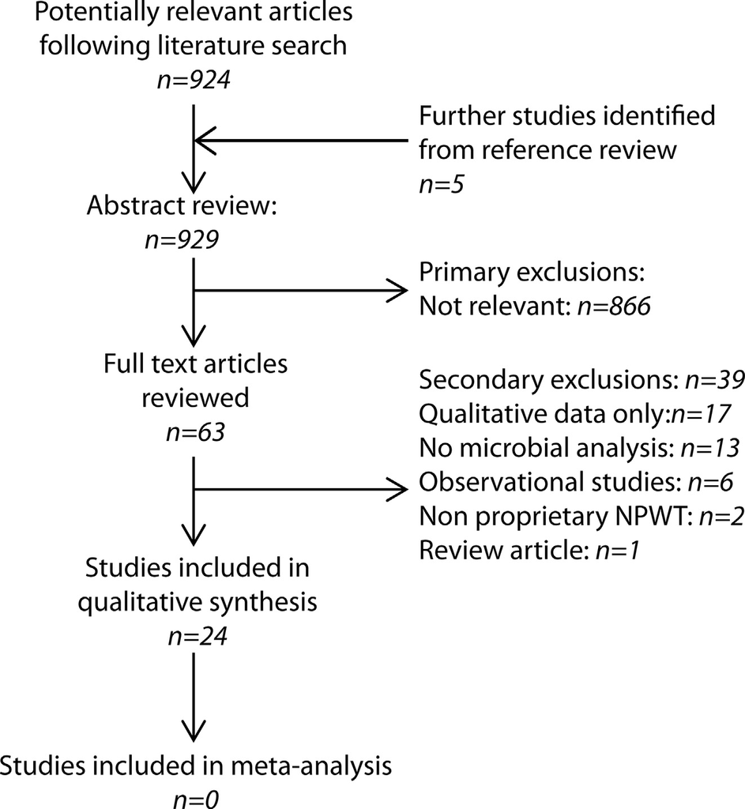

Figure 1

Literature search and study selection.

Table 1

Results summary from experimental studies.

Reference

Features

Findings

Notes

Morykwas<sup>1</sup>

Porcine wound model

inoculated with S. aureus

(3) and Staphylococcus

epidermidis (2)

CFU/g signiﬁcantly reduced between

day 4 and 5 with TNP only. No

difference between bacterial strains

High inoculum (10<sup>8</sup>organisms)

Only signiﬁcant difference was between day

4 and 5, and error bars indicate variation

atypically large compared with rest of

experiment.

Signiﬁcance reliant on rise in CFU/g in

control, which was against the trend for the

remainder of the experimental period

Boone<sup>8</sup>

Porcine wound model

Comparison between NPWT,

silver-impregnated

management of wounds

inoculated with multiple

organisms over 7 days

Overall, bacterial bioburden

increased over duration of study,

peaking at day 4

No signiﬁcant difference in overall

bacterial bioburden between NPWT,

silver-impregnated foam þ NPWT or

control dressings

Most wounds cultured additional

species at day 7, including Proteus, E.

coli and b-haemolytic Streptococcus

Low inoculum (10<sup>7</sup>organisms) but longer

incubation time (72 h)

Different NPWT regimen (intermittent)

Assadian<sup>9</sup>

Non-viable (porcine) tissue

model inoculated with MRSA

Comparison of NPWT vs

NPWT dressings only

Bacterial growth kinetics similar with

or without NPWT (increase in

bacterial count over 48 h then

plateau)

Low inoculum (10<sup>6</sup>organisms)

Controlled for blood ﬂow and immune

system

Not representative of clinical practice

Zhou<sup>10</sup>

Porcine wound model

inoculated with S. aureus

Comparison of NPWT @

�75, �150, �225,

�300 mmHg with NPWT

dressings only and gauze

only

At day 3, 5 and 7, NPWT at all

pressures demonstrated signiﬁcant

reduction of bacterial count versus

either NPWT dressings only or gauze

only.

High inoculum (>10<sup>8</sup>organisms)

Bacterial count fell over 7 days in all

conditions

Stinner<sup>11</sup>

Goat open tibial fracture

model

Comparison of

NPWT � Acticoat as

interface

Addition of Acticoat reduced pre-

debridement bacterial counts for

both Pseudomonas and S. aureus at

all time points compared with NPWT

alone

NPWT alone reduced Pseudomonas

but increased S. aureus over 6 days

High inoculum (>10<sup>8</sup>organisms)

Results expressed as percentage of results

6 h post inoculum prior to ﬁrst debridement

Liu<sup>12</sup>

Murine burn model

Comparison of NPWT vs WTD

dressings in managing scald

infected with Pseudomonas

NPWT signiﬁcantly reduced

Pseudomonas compared with wet to

dry (WTD) dressings as measured by

both tissue culture and

bioluminescence up to day 7

High inoculum (50 ml 10<sup>9</sup>organisms)

Microbiology cultures blinded

High-quality study design and analysis

Lallis<sup>13</sup>

Goat open tibial fracture

model

Comparison of NPWT with

WTD dressings

NPWT (PU foam or gauze) signiﬁcantly

reduced pre- and post-debridement

Pseudomonas compared with WTD

dressings at all time points

NPWT (gauze) made no signiﬁcant

difference to pre- and post-

debridement S. aureus compared

with WTD dressings at any time point

(overall 6-day increase with both

dressings)

NPWT reduced Pseudomonas but

increased S. aureus over 6 days

High inoculum (>10<sup>8</sup>organisms)

Results expressed as percentage of results

6 h post inoculum prior to ﬁrst debridement

WTD dressing changes twice daily

Evidence from modiﬁed NPWT regimens

Two studies<sup>26,27</sup>compared the effect of NPWT with inter-

mittent instillation versus conventional NPWT and un-

treated control on Pseudomonas bioburden. Phillips et al.

concluded, on the basis of their ex-vivo porcine model, that

although conventional NPWT did not signiﬁcantly reduce

Pseudomonas bioburden compared to polyurethane foam

dressing control, additional periodic instillation antimicro-

bial

solutions

(1%

and

10%

povidone-iodine,

0.05%

chlorhexidine

gluconate,

0.1%

polyhexanide

biguanide

(PHMB) or 0.2% poly(diallyldimethylammonium chloride))

led to a signiﬁcant reduction in bioburden at 24 h.<sup>26</sup>In

contrast, Davis et al. found that at 21 days in their in vivo

porcine model, conventional NPWT did signiﬁcantly reduce

Pseudomonas bioburden when compared to polyurethane

foam dressing control, and they observed a further signiﬁ-

cant reduction in bioburden with periodic instillation of

0.01% PHMB or 0.9% saline, but this did not correlate with

any signiﬁcant change in wound healing.<sup>27</sup>

Table 1 (continued)

Reference

Features

Findings

Notes

Li<sup>24</sup>

Porcine blast injury model

Comparison of NPWT @ �5

to �35 kPa vs WTD dressings

in management of blast left

for 48 h

NPWT signiﬁcantly reduced both

aerobic and anaerobic bacterial

counts from day 1 post treatment at

�10 to �35 kPa (�75 to �263 mmHg)

at all time points (to day 20).

NPWT increased relative percentage

of S. epidermidis and group A Strep

beyond 14 days

No inoculum. Blast left for 48 h prior to

debridement and dressing.

Inﬂuence on Pseudomonas spp. unclear as

not present at start

Liu<sup>4</sup>

Rabbit wound model

Comparison of NPWT vs WTD

dressings in full thickness

wounds inoculated with S.

aureus over 8 days

NPWT signiﬁcantly reduced S. aureus

compared with WTD dressings as

measured by tissue culture at days 2,

4 and 8

No signiﬁcant difference observed at day 6

Li<sup>25</sup>

Rabbit wound model

Comparison of NPWT vs no

dressing in full thickness ear

wounds inoculated with S.

aureus over 13 days

NPWT signiﬁcantly reduced S. aureus

compared with no dressings from

post-operative day 8 (5 days after

inoculation and NPWT application)

Wounds inoculated on day 3 post wound

creation and NPWT applied 6 h later

Table 2

Results summary from randomised controlled trials.

Reference

Features

Findings

Notes

Moues<sup>14</sup>

Comparison of NPWT with

wet to dry dressings in

management of acute and

chronic wounds

No signiﬁcant change in overall bacterial

bioburden over duration of study for

either NPWT or control.

Signiﬁcant reduction in non-

fermentative gram-negative bacilli with

NPWT (vs control)

Signiﬁcant increase in S. aureus with

NPWT (vs control)

Better wound healing seen with

NPWT- did not correlate with

bacterial load

Microbiology cultures blinded

NPWT did not inﬂuence

Enterobacteriae or anaerobes

Braakenburg<sup>15</sup>

Comparison of NPWT with

various other dressings in

management of acute and

chronic wounds

Over study period, neither modality

signiﬁcantly reduced the number of

positive swabs from the wound bed (88%

e84%; NPWT vs 47% to 58%; alginate)

No bacterial sub-analysis

Tuncel<sup>16</sup>

Comparison of gauze-based

NPWT with polyhexanide-

soaked gauze dressings in

management of sub-acute

and chronic wounds

22 of 25 (NPWT) vs 16 of 25

(conventional) exhibited negative wound

cultures at study endpoint (P < 0.05)

Dynamic change in bacterial

bioburden unclear

No sub-analysis of which bacteria

were selectively reduced by NPWT

Monsen<sup>17</sup>

Comparison of NPWT with

alginate dressing in

management of perivascular

groin infections

Over 21 days, neither modality

signiﬁcantly reduced the number of

positive swabs from the wound bed (9 of

10 to 8 of 10; NPWT vs 8 of 10 to 6 of 10;

alginate)

NPWT resulted in better healing but

not attributable to changes in

bacterial bioburden

Of the 2 case series comparing NPWT against NPWT with

instillation of antimicrobials, Daeschlein et al.<sup>28</sup>found no

difference in microbial bioburden between the 2 groups,

whereas Goss et al.<sup>29</sup>found that the addition of periodic

antimicrobial instillation signiﬁcantly reduced the micro-

bial bioburden. No randomised controlled trials have yet

addressed the use of NPWT with periodic instillation of

antimicrobial

solutions.

The

results

from

inﬁltration-

assisted NPWT are shown in Table 4.

Stinner et al. found that the introduction of a silver-

impregnated interface reduced growth of both Pseudo-

monas and S. aureus.<sup>11</sup>In contrast, Boone et al. found that

silver-impregnated polyurethane foam did not inﬂuence the

bacterial bioburden of the wound bed.<sup>8</sup>

Discussion

We have found a lack of consensus in the literature regarding

the inﬂuence of NPWT on the bacterial bioburden of the

wound bed. Seven studies concluded that NPWT signiﬁcantly

reduced the bacterial bioburden of the wound bed relative to

control dressings on at least one time point over the experi-

mental period.<sup>1,4,10,16,18,24,25</sup>In contrast, 8 studies concluded

that NPWT did not inﬂuence the bacterial bioburden inde-

pendently. Five studies suggested that the inﬂuence of NPWT

on was bacterial species-dependent, suppressing growth of

Pseudomonas and/or other non-fermentative gram-negative

bacilli such as acinetobacter.<sup>11</sup><sup>e</sup><sup>14,22</sup>The results of this sys-

tematic review call into question the ﬁndings of the seminal

paper by Morykwas et al.,<sup>1</sup>which is often quoted as justiﬁ-

cation for using NPWT on contaminated wounds in the

expectation that this therapy will cleanse the wound, facili-

tating reconstruction by minimising the extent of debride-

ment and/or the need to remove indwelling prostheses.<sup>31,32</sup>

Our results instead suggest that the relationship between

NPWT and bacterial growth kinetics is more complex and is

probably

species-dependent.

The

lack

of

a

deﬁnitive

conclusion on this point reﬂects the heterogeneous nature of

the experimental protocols, as half of the clinical studies

included were not designed to evaluate species-selectivity.

Moreover, studies reporting reduced deep infection rate

following open fracture treated with NPWT<sup>33</sup>and infection-

free prosthetic preservation with NPWT<sup>31</sup>both describe

radical debridement as part of the protocol, so the contri-

bution of NPWTto theoutcomes isunclear. We also found that

the baseline ﬂora was very different for wounds of different

sites and aetiologies. For example, combat extremity trauma

Table 3

Results summary from clinical studies.

Reference

Features

Findings

Notes

Tan<sup>18</sup>

Non-randomized

comparison of NPWT with

conventional dressings in

heterogeneous

osteomyelitis cohort

29 of 35 (NPWT) vs 15 of 33

(conventional) exhibited negative

wound cultures at study endpoint

(P < 0.05)

Uncertain how many samples were required

to conﬁrm negative bacterial bioburden

Some implants retained acutely. Long-term

salvage unclear

Weed<sup>19</sup>

Analysis of dynamics of

bacterial bioburden of

wound under NPWT

No signiﬁcant change in bacterial

bioburden identiﬁed from beginning

to end of the NPWT therapy

Very heterogeneous population (in-patient

and out-patient, acute and chronic wounds)

Accuracy of swab sampling method to

quantify bacterial load

No species analysis

Comparison of only ﬁrst and last culture

results

Isago<sup>20</sup>

Analysis of dynamics of

bacterial bioburden of

pressure ulcers under NPWT

Bacterial bioburden stable in 7 of 10

cases and minimized in 3 of 10 cases

Bacterial species minimized were

Pseudomonas in one case and S.

aureus in 3 cases (incl. MRSA in 2)

No prior debridement or antibiotics

Khashram<sup>21</sup>

Analysis of dynamics of

bacterial bioburden of

venous ulcers under NPWT

Median log10 CFU/cm2 increased

over duration of study

No change in species observed

Short duration

72 h between dressing changes

Sheppard<sup>22</sup>

Analysis of dynamics of

bacterial bioburden of

combat extremity trauma

under NPWT

167 biopsies negative; 75 biopsies

positive. Relative percentage of

positive biopsies increased over time

under NPWT

Relative percentage of biopsied

positive for pseudomonas decreased

over time

No evidence that NPWT reduced gram-

negative bioburden overall but did reduce

Pseudomonas bioburden

Only bioburden of >105 organisms included

as thought to be more clinically signiﬁcant

Pliakos<sup>23</sup>

Analysis of dynamics of

bacterial bioburden of

peritoneum after

laparotomy þ NPWT

following abdominal sepsis

Over the study period, the number of

positive bacterial cultures from

peritoneal aspirate increased from 19

of 39 to 30 of 39

No control intervention; so the role of NPWT

in increasing positive bacterial cultures is

uncertain.

Inﬂuence on Pseudomonas uncertain

exhibited a very different baseline ﬂora from chronic cuta-

neous wounds and intra-abdominal wounds. While this is not

surprising, it must be factored into any evaluation of the

capacity of NPWT to exert a dynamic effect on wound ﬂora.

Therefore, experimental wounds are useful, and the data

from these studies support the conclusion that NPWT selec-

tively suppresses Pseudomonas spp. This is based on 3

experimental studies<sup>11</sup><sup>e</sup><sup>13</sup>and 2 clinical studies.<sup>14,22</sup>Inter-

estingly, Anagnostakos and Mosser found that the bacterial

species identiﬁed on NPWT foam correlated poorly with the

species cultures from tissue specimens harvested at the

wound bed.<sup>35</sup>Whether NPWT suppresses anything else re-

mains conjectural.

Wound healing was found not to correlate with overall

bacterial bioburden. This calls into question the impor-

tance of the traditional infection threshold of 10<sup>5</sup>CFU/g of

tissue<sup>36</sup>and supports recent work demonstrating that in

some circumstances, colonisation in excess of 10<sup>5</sup>CFU/g

may not adversely affect healing.<sup>37,38</sup>The observation is

species dependent, with impaired healing at lower indi-

vidual bacterial biodensity in the presence of high virulence

or bacterial synergism<sup>37,38</sup>; hence, the importance of the

particular ﬂoral combination in each wound and, by

extension, the inﬂuence of NPWT on that combination.

The implications of this study are twofold. First, the

ﬁndings suggest that NPWT should not be used in the

expectation that it can clear the wound of bacterial

contamination, thereby avoiding the difﬁcult reconstructive

decisions. Rather, it should be used as an adjunct to

deﬁnitive surgical management.<sup>39</sup>Second, the acknowl-

edgement that bacteria proliferate under NPWT and on

polyurethane foam emphasises the need for regular dressing

changes combined with debridement and/or irrigation<sup>34,35</sup>

when treating chronic wounds. The efﬁcacy of antibacte-

rial foams and interface materials has been reported in small

clinical series<sup>40,41</sup>and demonstrated in an in vitro model.<sup>42</sup>

However, there is no clear consensus in the literature to

deﬁne how these materials inﬂuence bacterial bioburden in

various clinical settings.<sup>8,11</sup>Similarly, the use of NPWT de-

vices that permit instillation of saline or antibacterial solu-

tions has shown promise in clinical series.<sup>43,44</sup>On the basis of

the limited data available, NPWT with instillation (NPWTi)

probably does inﬂuence bacterial bioburden, and this effect

is probably species dependent. The differences in bacterial

growth with gauze or polyurethane foam and the inﬂuence of

an interface material remain unclear.

There were a number of limitations to this study. First, it is

worth stressing that from a clinical point of view, our interest

lies in infection-free wound healing and/or wound bed

preparation prior to deﬁnitive surgical closure. The microbi-

ological environment of the wound bed and the extent to

which NPWT inﬂuences this is of interest only insofar as it may

be used to achieve this end. The microbiological proﬁle of

wounds is relevant because in practice, NPWT is used to

temporise and to manage difﬁcult wounds in circumstances

where infection of the wound bed might upgrade the recon-

structive requirements. As the presence of bacterial patho-

gens promotes inﬂammatory cell recruitment and thus the

Table 4

Results summary from studies evaluating instillation NPWT.

Reference

Features

Findings

Notes

Phillips<sup>26</sup>

(experimental)

Porcine skin explant model

Comparison of NPWTi (8 instillation

solutions) with NPWT and untreated

control

NPWTi with most antiseptic solutions

signiﬁcantly reduced bioburden of

pseudomonas. Most effective were

10% povidone-iodine, 0.2% pDADMAC

and Prontosan.

NPWT alone made no signiﬁcant

reduction in bioburden

Inoculum of 10<sup>6</sup>CFU

Pseudomonas for 3.5 days

Analysis after 24 h therapy

Davis<sup>27</sup>

(experimental)

Pig skin wound model, 6 wounds per

pig, 6 pigs

Comparison of control with NPWT and

NPWTi (0.9% saline or 0.01% PHMB,

high or low ﬂow)

NPWT and NPWTi signiﬁcantly

reduced Pseudomonas bioburden vs

control at 21 days.

No difference in wound healing

between NPWT and NPWTi, although

both better than control.

Inoculum of 500 CFU

Pseudomonas for 3 days

Quantum� pump and black

foam (ITI)

Daeschlein<sup>28</sup>

(clinical)

Non-randomized comparison of NPWT

with NPWTi in chronic wound cohort.

Over study period (2e7 days per

wound), number of CFU per wound

swab did not change signiﬁcantly in

either group

Bacterial ﬂora appeared unrelated to

clinical outcome (successful graft

take).

Signiﬁcant baseline

differences in age, BMI,

comorbidities and wound

size between groups.

Goss<sup>29</sup>

(clinical)

Sequential allocation of chronically

infected lower limb wounds to NPWT

or NPWTi

Over 7 days, wounds treated with

NPWTi (quarter strength Dakin’s

solution) reduced bioburden by

10.6 � 10<sup>6</sup>per gram of tissue, while

those treated with conventional

NPWT increased bioburden by

28.7 � 10<sup>6</sup>per gram.

expression of pro-inﬂammatory cytokines, NPWT may in part

act by reducing the inﬂammatory cell inﬁltrate and tip the

balance towards an anabolic environment.<sup>3</sup>Hence, the

relationship between bacterial bioburden and wound healing

under NPWT is a complex.

Second, the heterogeneity of the included studies pre-

cluded meaningful meta-analysis and renders this review

descriptive in nature. Third, it is clear that when evaluating

wounds treated with NPWT, the growth kinetics of a species

must be evaluated in the context of the others seeking to

populate the same niche. This adds a potentially con-

founding variable into our analyses, which is difﬁcult to

control. Interestingly, 2 studies using S. aureus as a control

species to evaluate the growth kinetics of Pseudomonas

aeruginosa reported that the tissue density of S. aureus

increased in proportion to the fall in tissue density of P.

aeruginosa. This adds to the evidence that NPWT has a

selective action on bacterial growth. In clinical practice,

were the gram-positive cocci at the wound bed highly

virulent, such as a Panton-Valentine leukocidin (PVL)-con-

taining S. aureus, this may result in clinical deterioration.

Indeed, positivity for PVL-containing S. aureus at the

wound bed may be a contraindication to the use of NPWT on

the basis of these results. As to why NPWT negatively im-

pacts on Pseudomonas spp., proliferation may be impaired

either by an immune-mediated effect, an unfavourable

change in the bacterial microenvironment including an ef-

fect on the bioﬁlm as reported by Li et al.,<sup>25</sup>or by a direct

action on bacterial metabolism. Moreover, it is uncertain

how the wider change in the microenvironment under

NPWT, such as local tissue oxygenation and pH alters bac-

terial behaviour.<sup>45</sup>There are, at present, insufﬁcient data

to establish the extent to which the observed effect of

NPWT on Pseudomonas is species or strain-speciﬁc.

We have yet to fully appreciate how NPWT inﬂuences

commensals, pathogens and nosocomial contaminant spe-

cies at the wound bed. Further work must attempt to

delineate the bacterial species-speciﬁc effects of NPWT

and how to manipulate the microbiological proﬁle of the

wound by using NPWT to enhance healing. Arguably, such

work requires more focus on the experimental models as

here we have end-to-end control over the wound environ-

ment, and the larger models (such as porcine wound

models) are likely to replicate the human wound environ-

ment. More work is also needed to evaluate the inﬂuence of

NPWT on bacterial growth within ischaemic wounds.

In summary, the common assertion that NPWT reduces

the bacterial growth within the subjacent wound is an over-

simpliﬁcation. Instead, NPWT may have a role in sup-

pressing the proliferation of selective bacterial species

such as NFGNB including P. aeruginosa, but in doing so,

there is evidence that the depopulated niche is exploited

by gram-positive cocci. Future work should seek to deﬁne

the growth kinetics of common wound pathogens under

NPWT, and NPWT should not be used as a substitute for

adequate surgical debridement and, where indicated,

prompt deﬁnitive closure.

Conﬂict of interest

None.

Appendix A. Supplementary data

Supplementary data related to this article can be found at

http://dx.doi.org/10.1016/j.bjps.2017.05.027.

References

1. Morykwas MJ, Argenta LC, Shelton-Brown EI, McGuirt W. Vac-

uum-assisted closure: a new method for wound control and

treatment: animal studies and basic foundation. Ann Plast Surg

1997:553e62.

2. Argenta LC, Morykwas MJ. Vacuum-assisted closure: a new

method for wound control and treatment: clinical experience.

Ann Plast Surg 1997;38:563e77.

3. Glass GE, Murphy GF, Esmaeili A, Lai L-M, Nanchahal J. Sys-

tematic review of molecular mechanism of action of negative-

pressure wound therapy. Br J Surg 2014;101:1627e36.

4. Liu D, Zhang L, Li T, et al. Negative-pressure wound therapy

enhances local inﬂammatory responses in acute infected soft-

tissue wound. Cell Biochem Biophys 2014;70:539e47.

5. Moher D, Liberati A, Tetzlaff J, Altman DG, Prisma Group.

Preferred reporting Items for systematic reviews and meta-

analyses: the PRISMA statement. PLOS Med 2009;6:e1000097.

6. Guyatt G, Oxman AD, Akl EA, et al. GRADE guidelines: 1.

Introduction - GRADE evidence proﬁles and summary of ﬁndings

tables. J Clin Epidemiol 2011;64:383e94.

7. Guyatt GH, Oxman AD, Sultan S, et al. GRADE guidelines: 9.

Rating up the quality of evidence. J Clin Epidemiol 2011;64:

1311e6.

8. Boone D, Braitman E, Gentics C, et al. Bacterial burden and

wound outcomes as inﬂuenced by negative pressure wound

therapy. Wounds 2010;22:32e7.

9. Assadian

O,

Assadian

A,

Stadler

M,

Diab-Elschahawi

M,

Kramer A. Bacterial growth kinetic without the inﬂuence of the

immune system using vacuum-assisted closure dressing with

and without negative pressure in an in vitro wound model. Int

Wound J 2010;7:283e9.

10. Zhou M, Yu A, Wu G, Xia C, Hu X, Qi B. Role of different

negative pressure values in the process of infected wounds

treated by vacuum-assisted closure: an experimental study. Int

Wound J 2013;10:508e15.

11. Stinner DJ, Waterman SM, Masini BD, Wenke JC. Silver dress-

ings augment the ability of negative pressure wound therapy to

reduce bacteria in a contaminated open fracture model. J

Trauma 2011;71:S147e50.

12. Liu Y, Zhou Q, Wang Y, et al. Negative pressure wound therapy

decreases mortality in a murine model of burn-wound sepsis

involving pseudomonas aeruginosa infection. PLoS One 2014;9:

1e7.

13. Lalliss SJ, Stinner DJ, Waterman SM, Branstetter JG, Masini BD,

Wenke JC. Negative pressure wound therapy reduces pseudo-

monas

wound

contamination

more

than

Staphylococcus

aureus. J Orthop Trauma 2010;24:598e602.

14. Moues C, Vos M, Van Den Bemd G. Young Investigator Award

Article: bacterial load in relation to vacuum-assisted closure

wound therapy: a prospective randomized trial. Wound Repair

Regen 2004:11e7.

15. Braakenburg A, Obdeijn MC, Feitz R, van Rooij IALM, van

Griethuysen AJ, Klinkenbijl JHG. The clinical efﬁcacy and

cost effectiveness of the vacuum-assisted closure technique

in the management of acute and chronic wounds: a ran-

domized controlled trial. Plast Reconstr Surg 2006;118:

390e7. 400.

16. Tuncel U, Erkorkmaz U, Turan A. Clinical evaluation of gauze-

based

negative

pressure

wound

therapy

in

challenging

wounds. Int Wound J 2013;10:152e8.

17. Monsen C, Wann-Hansson C, Wictorsson C, Acosta S. Vacuum-

assisted wound closure versus alginate for the treatment of

deep perivascular wound infections in the groin after vascular

surgery. J Vasc Surg 2014;59:145e51.

18. Tan Y, Wang X, Li H, et al. The clinical efﬁcacy of the vacuum-

assisted closure therapy in the management of adult osteo-

myelitis. Arch Orthop Trauma Surg 2011;131:255e9.

19. Weed T, Ratliff C, Drake DB. Quantifying bacterial bioburden

during negative pressure wound therapy. Ann Plast Surg 2004;

52:276e9.

20. Isago T, Nozaki M, Kikuchi Y, Honda T, Nakazawa H. Negative-

pressure dressings in the treatment of pressure ulcers. J Der-

matol 2003;30:299e305.

21. Khashram M, Huggan P, Ikram R, Chambers S, Roake J, Lewis D.

Effect of TNP on the microbiology of venous leg ulcers: a pilot

study. J Wound Care 2009;18:164e7.

22. Sheppard FR, Keiser P, Craft DW, et al. The majority of US

combat casualty soft-tissue wounds are not infected or colo-

nized upon arrival or during treatment at a continental US

military medical facility. Am J Surg 2010;200:489e95.

23. Pliakos I, Michalopoulos N, Papavramidis TS, Arampatzi S, Diza-

Mataftsi E, Papavramidis S. The effect of vacuum-assisted

closure in bacterial clearance of the infected abdomen. Surg

Infect 2014;15:18e23.

24. Li J, Topaz M, Tan H, et al. Treatment of infected soft tissue

blast injury in swine by regulated negative pressure wound

therapy. Ann Surg 2013;257:335e44.

25. Li T, Zhang L, Han L, et al. Early application of negative

pressure wound therapy to acute wounds contaminated with

Staphylococcus aureus: an effective approach to preventing

bioﬁlm formation. Exp Ther Med 2016;11:769e76.

26. Phillips PL, Yang Q, Schultz GS. The effect of negative pressure

wound therapy with periodic instillation using antimicrobial

solutions on Pseudomonas aeruginosa bioﬁlm on porcine skin

explants. Int Wound J 2013;10:48e55.

27. Davis K, Bills J, Barker J, Kim P, Lavery L. Simultaneous irri-

gation and negative pressure wound therapy enhances wound

healing and reduces wound bioburden in a porcine model.

Wound Repair Regen 2013;21:869e75.

28. Daeschlein G, Napp M, Lutze S, et al. Comparison of the effect

of negative pressure wound therapy with and without instal-

lation of polyhexanide on the bacterial kinetic in chronic

wounds. Wound Med 2016;13:5e11.

29. Goss SG, Schwartz JA, Facchin F, Avdagic E, Gendics C,

Lantis JC. Negative pressure wound therapy with instillation

(NPWTi)

better

reduces

post-debridement

bioburden

in

chronically infected lower extremity wounds than NPWT alone.

J Am Coll Clin Wound Spec 2012;4:74e80.

30. Moues CM, van den Bemd GJCM, Heule F, Hovius SER.

Comparing conventional gauze therapy to vacuum-assisted

closure wound therapy: a prospective randomised trial. J

Plast Reconstr Aesthetic Surg 2007;60:672e81.

31. Mayer D, Hasse B, Koelliker J, et al. Long-term results of

vascular graft and artery preserving treatment with negative

pressure wound therapy in Szilagyi grade III infections justify a

paradigm shift. Ann Surg 2011;254:754e9.

32. Tocco MP, Ballardini M, Masala M, Perozzi A. Post-sternotomy

chronic osteomyelitis: is sternal resection always necessary?

Eur J Cardio-thoracic Surg 2013;43:715e21.

33. Stannard JP, Volgas DA, Stewart R, McGwin G, Alonso JE.

Negative pressure wound therapy after severe open fractures:

a prospective randomized study. J Orthop Trauma 2009;23:

552e7.

34. Yusuf E, Jordan X, Clauss M, Borens O, Ma¨der M, Trampuz A.

High bacterial load in negative pressure wound therapy (NPWT)

foams used in the treatment of chronic wounds. Wound Repair

Regen 2011;21:677e81.

35. Anagnostakos K, Mosser P. Bacterial identiﬁcation on NPWT

foams: clinical relevance or contamination? J Wound Care

2012;21:226e39.

36. Robson M, Heggers J. Bacterial quantiﬁcation of open wounds.

Mil Med 1969;134:19e24.

37. Bowler PG. The 10(5) bacterial growth guideline: reassessing

its clinical relevance in wound healing. Ostomy Wound Manag

2003;49:44e53.

38. Edwards R, Harding KG. Bacteria and wound healing colonisa-

tion contamination. Curr Opin Infect Dis 2004;17:91e6.

39. Baillot R, Cloutier D, Montalin L, et al. Impact of deep sternal

wound infection management with vacuum-assisted closure

therapy followed by sternal osteosynthesis: a 15-year review of

23 499 sternotomies. Eur J Cardio-thoracic Surg 2010;37:

880e7.

40. Payne JL, Ambroslo AM. Evaluation of an antimicrobial silver

foam dressing for use with V.A.C.<sup>�</sup>therapy: morphological,

mechanical, and antimicrobial properties. J Biomed Mater Res

Part B Appl Biomater 2009;89:217e22.

41. Gerry R, Kwei S, Bayer L, Breuing KH. Silver-impregnated

vacuum-assisted closure in the treatment of recalcitrant

venous stasis ulcers. Ann Plast Surg 2007;59:58e62.

42. Ngo QD, Vickery K, Deva AK. The effect of topical negative

pressure on wound bioﬁlms using an in vitro wound model.

Wound Repair Regen 2012;20:83e90.

43. Gabriel A, Shores J, Heinrich C, et al. Negative pressure wound

therapy with instillation: a pilot study describing a new method

for treating infected wounds. Int Wound J 2008 Jun;5:

399e413.

44. Brinkert D, Ali M, Naud M, Maire N, Trial C, Te´ot L. Negative

pressure wound therapy with saline instillation: 131 patient

case series. Int Wound J 2013;10:56e60.

45. Schaible B, Taylor CT, Schaffer K. Hypoxia increases antibiotic

resistance in Pseudomonas aeruginosa through altering the

composition of multidrug efﬂux pumps. Antimicrob Agents

Chemother 2012;56:2114e8.